# ASSESSMENT OF THE MEDITERRANEAN SWORDFISH STOCK BY MEANS OF ASSESSMENT FOR ALL INITIATIVE (a4a)

## Biological Reference Points

The four different runs of the a4a model were used to calculate reference points based on yield per recruit analysis. A Beverton Holt Stock Recruitment relationship was assumed. iven the lack of sufficient data for a proper fit an empirical relationship with high steepness value was developed. The equilibrium curves are presented in **Figures 31 - 34**, for each different run and the reference points values are presented in **Tables 2 - 5**

### Candidate run assuming constant M

**Table 2**. Reference points for candidate run assuming constant M.

| refpt | harvest | yield | rec | ssb | biomass |
| --- | --- | --- | --- | --- | --- |
| f0.1 | 0.2045299 | 13420.78 | 900108.2 | 49156.64 | 71596.12 |
| msy | 0.3834245 | 14575.71 | 898391.1 | 25319.24 | 45942.75 |
| virgin | 0.0000000 | 0.00 | 901331.6 | 148325.17 | 173227.44 |
| spr.30 | 0.2288609 | 13788.02 | 899913.7 | 44427.17 | 66602.83 |

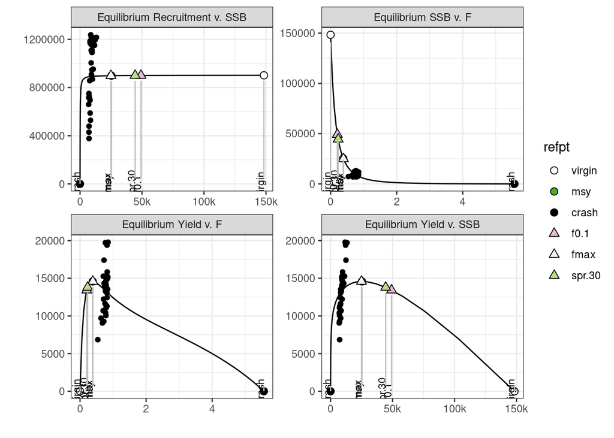

**Figure 31**. Equilibrium curves for candidate run assuming constant M. Relationship between SSB and F, recruitment and F, yield and F and SSB at equilibrium

### Candidate run assuming Lorenzen M vector

**Table 3**. Reference points for candidate run assuming Lorenzen M vector.

| refpt | harvest | yield | rec | ssb | biomass |
| --- | --- | --- | --- | --- | --- |
| f0.1 | 0.1772946 | 14000.75 | 1201295 | 60457.04 | 84882.65 |
| msy | 0.3489969 | 15325.44 | 1199292 | 30061.70 | 52735.31 |
| virgin | 0.0000000 | 0.00 | 1202622 | 182217.88 | 208745.83 |
| spr.30 | 0.1992125 | 14407.09 | 1201082 | 54595.27 | 78782.91 |

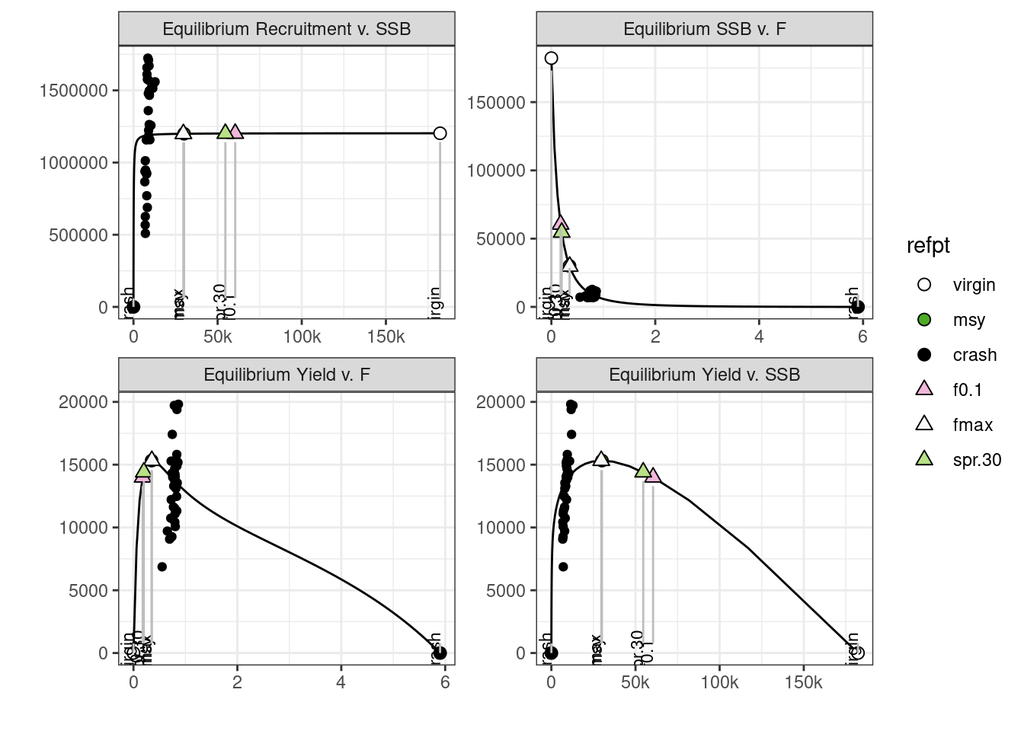

**Figure 32**. Equilibrium curves for candidate run assuming Lorenzen M vector. Relationship between SSB and F, recruitment and F, yield and F and SSB at equilibrium

### Discards run assuming constant M

**Table 4**. Reference points for discards run assuming constant M.

| refpt | harvest | yield | rec | ssb | biomass |
| --- | --- | --- | --- | --- | --- |
| f0.1 | 0.1989143 | 12732.28 | 943967.9 | 46624.80 | 68019.79 |
| msy | 0.3758470 | 13847.62 | 942076.2 | 24055.44 | 43693.34 |
| virgin | 0.0000000 | 0.00 | 945315.2 | 139573.36 | 163305.22 |
| spr.30 | 0.2249062 | 13111.95 | 943734.8 | 41801.74 | 62921.36 |

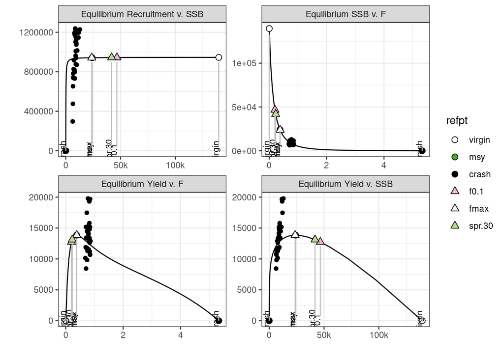

**Figure 33**. Equilibrium curves for discards run assuming constant M. Relationship between SSB and F, recruitment and F, yield and F and SSB at equilibrium

### Discards run assuming Lorenzen M vector

**Table 5**. Discards run assuming Lorenzen M vector. Reference points.

| refpt | harvest | yield | rec | ssb | biomass |
| --- | --- | --- | --- | --- | --- |
| f0.1 | 0.1758043 | 12896.20 | 1261151 | 54239.36 | 77150.77 |
| msy | 0.3494748 | 14138.31 | 1258795 | 26891.59 | 48114.61 |
| virgin | 0.0000000 | 0.00 | 1262700 | 162726.30 | 187623.46 |
| spr.30 | 0.1988355 | 13291.43 | 1260889 | 48747.81 | 71420.93 |

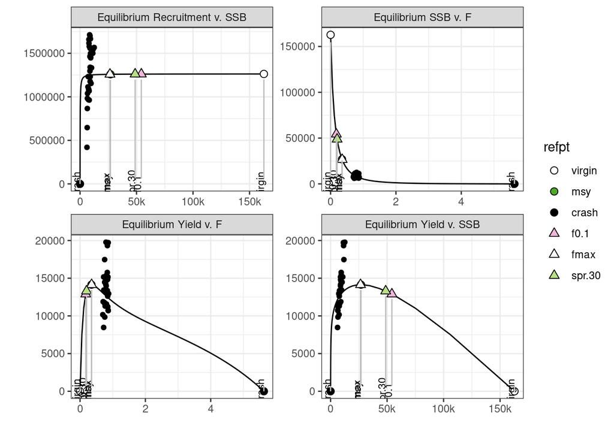

**Figure 34**. Discards run assuming Lorenzen M vector. Equilibrium curves. Relationship between SSB and F, recruitment and F, yield and F and SSB at equilibrium

## Selectivity

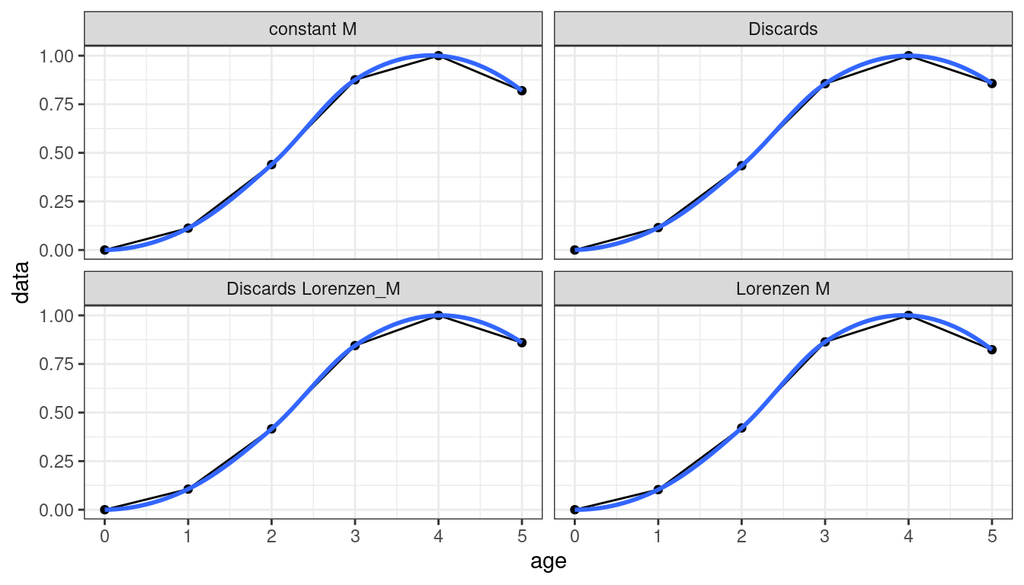

**Figure 35**. Estimates of selectivity curves by age from the different model runs.

## MCMC fit

MCMC runs were conducted for the two candidate runs as an alternative to the maximum likelihood estimation (MLE) that is being used as a default estimation procedure in the assessment. Comparisons of the results between the two approaches are presented in the **Figures 36 - 37**. In the **Tables 6 - 7** the coverage of the confidence intervals of both SSB and F are presented, for the different values of the tuning parameter of the MCMC algorithm, mcprobe. In theory, acceptance rate should be around 0.3 - 0.4.

### MCMC run for candidate run assuming constant M

**Table 6**. Values of mcprobe, SSB CI coverage, F CI coverage and acceptance rate; mcprobe = 0.4 has the best compromise between acceptance rate and CI coverage.

|  | mcprobe | ssbcov | fcov | accrate |
| --- | --- | --- | --- | --- |
| 0.5 | 0.5 | 0.8000000 | 0.7933333 | 0.34270 |
| 0.4 | 0.4 | 0.8266667 | 0.7933333 | 0.34053 |
| 0.3 | 0.3 | 0.7800000 | 0.7866667 | 0.26248 |
| 0.2 | 0.2 | 0.8200000 | 0.8133333 | 0.27199 |
| 0.1 | 0.1 | 0.7866667 | 0.7666667 | 0.32675 |
| 0 | 0.0 | 0.8066667 | 0.8133333 | 0.29609 |

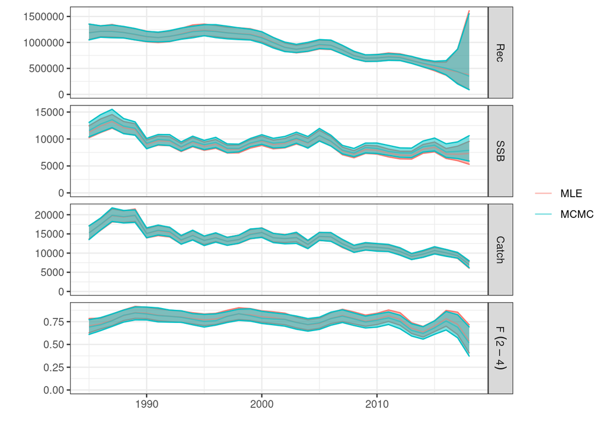

**Figure 36**. MCMC fit and MLE fit for the candidate run assuming constant M

### MCMC run for candidate run assuming Lorenzen M vector

**Table 7**. Values of mcprobe, SSB CI coverage, F CI coverage and acceptance rate; mcprobe = 0.2 has the best compromise between acceleration rate and CI coverage.

|  | mcprobe | ssbcov | fcov | accrate |
| --- | --- | --- | --- | --- |
| 0.5 | 0.5 | 0.7666667 | 0.7866667 | 0.34214 |
| 0.4 | 0.4 | 0.8066667 | 0.7933333 | 0.34197 |
| 0.3 | 0.3 | 0.8266667 | 0.8133333 | 0.26285 |
| 0.2 | 0.2 | 0.8400000 | 0.7866667 | 0.35199 |
| 0.1 | 0.1 | 0.8266667 | 0.7800000 | 0.32375 |
| 0 | 0.0 | 0.7800000 | 0.8133333 | 0.29594 |

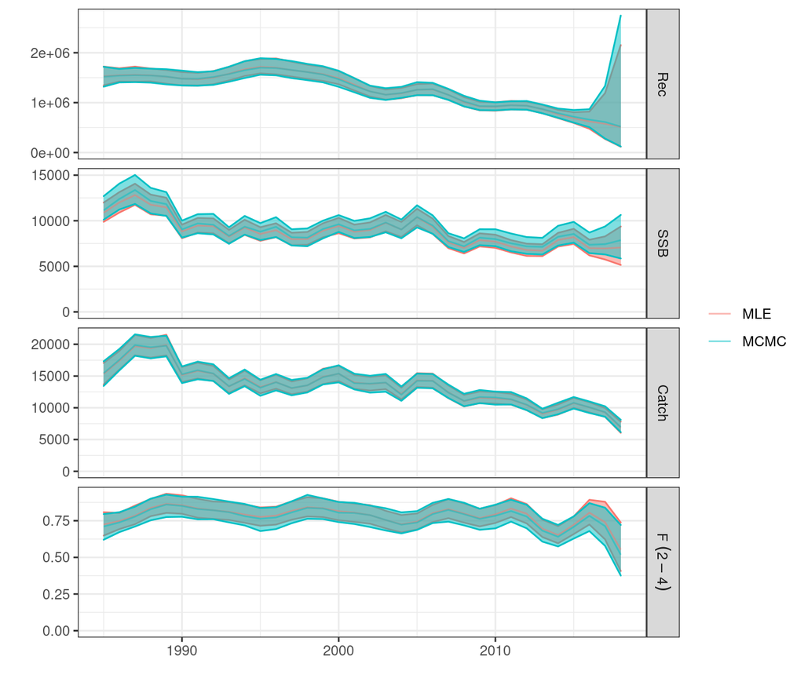

**Figure 37**. MCMC fit and MLE fit for the candidate run assuming Lorenzen M vector.

# Discussion

- In all four different runs the results for terminal years were quite similar. The inclusion of discards in both cases resulted in higher estimations of recruitment, especially in the early years, compared to the ones without the discards. All results seemed robust in terms of retrospective analysis. Residuals did not show any particular trend in all cases, but the absence of a tuning index for the late ages as well as the recruitment, led to some low residual values. The MCMC runs that conducted to test the two candidate models in uncertainty robustness gave pretty similar results.
- There are some core differences between XSA assessment approach and a4a. The statistical basis of the a4a allows for more careful considerations of data quality and their impact on the uncertainty estimations. Catch-at-age matrices are not assumed without error, while annual variability in estimates of both age composition and survey indices can be included. In XSA catchability coefficient is assumed constant, whereas in a4a can vary over time.
- Although catches have declined in the recent years and harvest rates are at lower levels than the previous decade, recruitment appears to follow declining trends. Therefore the robustness of reference points assuming in practice constant recruitment around the average of the entire time series is questionable. Given, that the model runs do not allow proper fit of a stock-recruitment relationship, it might be better to assume constant recruitment levels close to those observed in the last 10-15 years.

# References

Ernesto Jardim, Colin P. Millar, Iago Mosqueira, Finlay Scott, Giacomo Chato Osio, Marco Ferretti, Nekane Alzorriz, Alessandro Orio, What if stock assessment is as simple as a linear model? The a4a initiative, ICES Journal of Marine Science, Volume 72, Issue 1, January 2015, Pages 232–236, https://doi.org/10.1093/icesjms/fsu050

Fournier, D.A., Skaug, H.J., Ancheta, J., Ianelli, J., Magnusson, A., Maunder, M.N., Nielsen, A., and Sibert, J. 2012. AD Model Builder: using automatic differentiation for statistical inference of highly parameterized complex nonlinear models. Optim. Methods Softw. 27:233-249.

ICCAT, 2020. REPORT OF THE 2020 ICCAT INTERSESSIONAL MEETING OF THE SWORDFISH SPECIES GROUP. https://tinyurl.com/ycqfhjzl.

L. T. Kell, I. Mosqueira, P. Grosjean, J-M. Fromentin, D. Garcia, R. Hillary, E. Jardim, S. Mardle, M. A. Pastoors, J. J. Poos, F. Scott, R. D. Scott, FLR: an open-source framework for the evaluation and development of management strategies, ICES Journal of Marine Science, Volume 64, Issue 4, May 2007, Pages 640–646, https://doi.org/10.1093/icesjms/fsm012

R Core Team (2020). R: A language and environment for statistical computing. R Foundation for Statistical Computing, Vienna, Austria. URL http://www.R-project.org/

SCRS 2020/021. UPDATED STANDARDIZED SWORDFISH CATCH RATES FROM THE GREEK SURFACE LONGLINE FISHERIES OPERATING IN THE E. MEDITERRANEAN.

SCRS 2020/026. UPDATED CATCH RATES OF SWORDFISH *(XIPHIAS GLADIUS)* CAUGHT BY THE MOROCCAN LONGLINE FLEET IN THE MEDITERRANEAN SEA, 2012-2019

SCRS 2020/027. AN UPDATE OF THE SWORDFISH FISHERY IN THE LIGURIAN SEA (WESTERN MEDITERRANEAN) WITH A PRELIMINARY ATTEMPT TO STANDARDIZE THE MESOPELAGIC LONGLINE CPUEs.

SCRS 2020/028. ESTIMATION OF UNDERSIZED MEDITERRANEAN SWORDFISH *(Xiphias gladius)* CATCHES BETWEEN 2008 – 2018 FOR THE LONGLINE MAIN FLEETS.

SCRS 2020/043. Standardized Catch Rates for the Mediterranean Swordfish (*Xiphias gladius* Linnaeus, 1758) from the Spanish Longline Fishery. 1988-2018.

Tserpes, G., Peristeraki, P., Di Natale, A., Mangano, A. 2011. Analysis of swordfish (Xiphias gladius) catch rates in the central-eastern Mediterranean. Collect. Vol. Sci. Pap. ICCAT, 66(4): 1495-1505.

Wood, S.N. (2003) Thin-plate regression splines. Journal of the Royal Statistical Society (B) 65(1):95-114.